# Donor Retention Prediction Project

Artea Myftiu

November 16, 2025

# 1 1. Executive Summary

This project builds predictive models to estimate whether each donor will donate again in 2018. Using historical donation behavior from multiple years, we:

- Construct features summarizing **recency, frequency and monetary** behavior.
- Train several models:
  - Logistic regression (full and forward stepwise–selected)
  - Decision trees (default and tuned)
  - Bagged trees
  - Random forest
  - Gradient boosting (XGBoost)
- Evaluate models on a hold-out **2018 test set** using:
  - AUC
  - Sensitivity
  - Specificity

We then translate the best predictive model into **business impact** by simulating different mailing strategies (what % of donors to contact) and computing cost, revenue, and net profit. We also build a **lift chart** to show how much better the model is than a random strategy.

# 2 2. Business Problem & Data

The organization wants to **predict which donors are most likely to give again** so that marketing mailers can be focused on high-probability donors. Mailing everyone is expensive and wastes budget on low-probability donors.

We use five data files:

- `donors.csv` — static donor demographics and segmentation
- `gifts.csv` — donation history (donor, date, amount)
- `basetable_2017.csv` — engineered features and target for 2017
- `basetable_2018.csv` — engineered features and target for 2018 (test)
- `feature_catalog.csv` — documentation of the engineered features

## 2.1 2.1 Load Data

## 2.2 2.2 Exploratory Data Analysis

We first explore the donor universe and the basetables to understand the size of the dataset, missing values, and donation behavior.

```
## Rows: 5,000
## Columns: 7
## $ donor_id   <dbl> 1, 2, 3, 4, 5, 6, 7, 8, 9, 10, 11, 12, 13, 14, 15, 16, 17, …
## $ age        <dbl> 66, 22, 58, 61, 52, 50, 47, 55, 42, 70, 52, 42, 55, 50, 73,…
## $ gender     <chr> "M", "M", "F", "M", "F", "F", "M", "F", "F", "F", "F", "F",…
## $ country    <chr> "UK", "USA", "UK", "USA", "UK", "Germany", "USA", "USA", "U…
## $ region     <chr> "South", "West", "South", "North", "South", "South", "West"…
## $ segment    <chr> "Bronze", "Gold", "Silver", "Gold", "Gold", "Gold", "Bronze…
## $ birth_year <dbl> 1952, 1996, 1960, 1957, 1966, 1968, 1971, 1963, 1976, 1948,…
```

```
##     donor_id         age           gender            country
##  Min.   :   1   Min.   :18.00   Length:5000        Length:5000
##  1st Qu.:1251   1st Qu.:47.00   Class :character   Class :character
##  Median :2500   Median :58.00   Mode  :character   Mode  :character
##  Mean   :2500   Mean   :58.09
##  3rd Qu.:3750   3rd Qu.:69.00
##  Max.   :5000   Max.   :95.00
##     region            segment            birth_year
##  Length:5000        Length:5000        Min.   :1923
##  Class :character   Class :character   1st Qu.:1949
##  Mode  :character   Mode  :character   Median :1960
##                                        Mean   :1960
##                                        3rd Qu.:1971
##                                        Max.   :2000
```

```
## Rows: 32,684
## Columns: 4
## $ id       <dbl> 1, 1, 1, 1, 2, 2, 2, 2, 2, 2, 3, 3, 3, 3, 3, 3, 3, 3, 3, 3, 3…
## $ date     <date> 2013-11-14, 2014-05-29, 2015-05-07, 2015-12-10, 2012-03-01, …
## $ amount   <dbl> 24.74, 48.40, 83.91, 68.94, 148.76, 24.27, 66.47, 256.56, 86.…
## $ donor_id <int> 1, 1, 1, 1, 2, 2, 2, 2, 2, 2, 3, 3, 3, 3, 3, 3, 3, 3, 3, 3, 3…
```

```
##        id            date                amount          donor_id
##  Min.   :   1   Min.   :2012-01-01   Min.   : 10.00   Min.   :   1
##  1st Qu.:1243   1st Qu.:2012-12-14   1st Qu.: 55.27   1st Qu.:1243
##  Median :2502   Median :2014-03-07   Median : 89.15   Median :2502
##  Mean   :2492   Mean   :2014-07-27   Mean   : 96.15   Mean   :2492
##  3rd Qu.:3732   3rd Qu.:2015-12-12   3rd Qu.:130.28   3rd Qu.:3732
##  Max.   :5000   Max.   :2018-12-31   Max.   :392.14   Max.   :5000
```

```
## [1] "2012-01-01" "2018-12-31"
```

```
## [1] 5000
```

```
## Rows: 900
## Columns: 32
## $ donor_id           <dbl> 5, 15, 16, 19, 27, 34, 36, 55, 61, 62, 66, 72, 74, …
## $ age                <dbl> 52, 73, 46, 61, 54, 67, 41, 47, 53, 70, 52, 75, 53,…
## $ gender             <chr> "F", "M", "F", "F", "F", "F", "M", "M", "M", "F", "…
## $ country            <chr> "UK", "UK", "UK", "Germany", "Canada", "Canada", "C…
## $ region             <chr> "South", "North", "South", "East", "North", "South"…
## $ segment            <chr> "Gold", "Silver", "Gold", "Gold", "Silver", "Gold",…
## $ birth_year         <dbl> 1966, 1945, 1972, 1957, 1964, 1951, 1977, 1971, 196…
## $ age_at_observation <dbl> 51, 72, 45, 60, 53, 66, 40, 46, 52, 69, 51, 74, 52,…
## $ recency_days_12m   <dbl> 227, 287, 130, 218, 365, 365, 365, 204, 315, 365, 3…
## $ frequency_12m      <dbl> 1, 2, 5, 2, 0, 0, 0, 3, 1, 0, 2, 1, 2, 4, 0, 0, 2, …
## $ monetary_total_12m <dbl> 136.39, 203.45, 584.69, 220.32, 0.00, 0.00, 0.00, 2…
## $ monetary_mean_12m  <dbl> 136.39000, 101.72500, 116.93800, 110.16000, 0.00000…
## $ monetary_max_12m   <dbl> 136.39, 113.42, 148.17, 121.03, 0.00, 0.00, 0.00, 1…
```

[output cut: 19 more lines]

```
## Rows: 651
## Columns: 32
## $ donor_id           <dbl> 4, 6, 13, 19, 23, 36, 42, 48, 51, 52, 60, 73, 94, 9…
## $ age                <dbl> 61, 50, 55, 61, 44, 41, 86, 66, 57, 34, 78, 77, 40,…
## $ gender             <chr> "M", "F", "F", "F", "M", "M", "M", "F", "F", "F", "…
## $ country            <chr> "USA", "Germany", "USA", "Germany", "Other", "Canad…
## $ region             <chr> "North", "South", "West", "East", "East", "West", "…
## $ segment            <chr> "Gold", "Gold", "Silver", "Gold", "Silver", "Silver…
## $ birth_year         <dbl> 1957, 1968, 1963, 1957, 1974, 1977, 1932, 1952, 196…
## $ age_at_observation <dbl> 61, 50, 55, 61, 44, 41, 86, 66, 57, 34, 78, 77, 40,…
## $ recency_days_12m   <dbl> 365, 135, 232, 192, 325, 121, 217, 365, 326, 365, 3…
## $ frequency_12m      <dbl> 0, 1, 4, 3, 1, 3, 1, 0, 1, 0, 1, 1, 2, 1, 2, 0, 0, …
## $ monetary_total_12m <dbl> 0.00, 178.35, 297.87, 461.16, 87.88, 402.72, 19.83,…
## $ monetary_mean_12m  <dbl> 0.0000, 178.3500, 74.4675, 153.7200, 87.8800, 134.2…
## $ monetary_max_12m   <dbl> 0.00, 178.35, 95.53, 232.88, 87.88, 155.69, 19.83, …
```

[output cut: 19 more lines]

```
##    Min. 1st Qu.  Median    Mean 3rd Qu.    Max.
##  0.0000  0.0000  0.0000  0.2122  0.0000  1.0000
```

```
##    Min. 1st Qu.  Median    Mean 3rd Qu.    Max.
##  0.0000  0.0000  0.0000  0.2043  0.0000  1.0000
```

```
##           donor_id                age             gender            country
##                  0                  0                  0                  0
##             region            segment         birth_year age_at_observation
##                  0                  0                  0                  0
##   recency_days_12m      frequency_12m monetary_total_12m  monetary_mean_12m
##                  0                  0                  0                  0
##   monetary_max_12m   monetary_min_12m   recency_days_24m      frequency_24m
##                  0                  0                  0                  0
## monetary_total_24m  monetary_mean_24m   monetary_max_24m   monetary_min_24m
##                  0                  0                  0                  0
##       amount_trend        count_trend      amount_growth lifetime_donations
##                  0                  0                  0                  0
##    lifetime_amount   days_since_first    days_since_last     donor_age_days
##                  0                  0                  0                  0
##   avg_days_between       is_new_donor     target_donated      target_amount
##                 12                  0                  0                  0
```

```
##           donor_id                age             gender            country
##                  0                  0                  0                  0
##             region            segment         birth_year age_at_observation
##                  0                  0                  0                  0
##   recency_days_12m      frequency_12m monetary_total_12m  monetary_mean_12m
##                  0                  0                  0                  0
##   monetary_max_12m   monetary_min_12m   recency_days_24m      frequency_24m
##                  0                  0                  0                  0
## monetary_total_24m  monetary_mean_24m   monetary_max_24m   monetary_min_24m
##                  0                  0                  0                  0
##       amount_trend        count_trend      amount_growth lifetime_donations
##                  0                  0                  0                  0
##    lifetime_amount   days_since_first    days_since_last     donor_age_days
##                  0                  0                  0                  0
##   avg_days_between       is_new_donor     target_donated      target_amount
##                  6                  0                  0                  0
```

| feature_name | feature_type | description | data_type |
| --- | --- | --- | --- |
| recency_days_12m | RFM_12m | Days since last donation (12-month window) | Numeric |
| frequency_12m | RFM_12m | Number of donations (12-month window) | Numeric |
| monetary_total_12m | RFM_12m | Total donation amount (12-month window) | Numeric |
| monetary_mean_12m | RFM_12m | Average donation amount (12-month window) | Numeric |
| monetary_max_12m | RFM_12m | Maximum donation amount (12-month window) | Numeric |
| monetary_min_12m | RFM_12m | Minimum donation amount (12-month window) | Numeric |

### 2.2.1 2.3 Question 1: Data Understanding

**a) What is the date range of the donation history? How many years of data are available?**  
From the gifts data, the donation dates range from **2012-01-01** to **2018-12-31**, which is roughly **7 years** of donation history.

**b) What percentage of donors have missing demographic information (age, gender, location)?**  
In our basetables, the key demographic fields (`age`, `gender`, `country`, `region`, `segment`) have **0 missing values**, so the percentage of donors with missing demographic information is effectively **0%**.

**c) Overall donation response rate across all historical campaigns**  
In `basetable_2017`, the mean of `target_donated` ≈ **0.212**  
In `basetable_2018`, the mean of `target_donated` ≈ **0.204**

So the overall response rate is around **20–21%**, meaning **most donors do not donate in the prediction window**. This confirms that the business problem is a **moderately imbalanced classification problem** where we care about lifting the probability of donation above this baseline.

**d) Data quality issues before modeling**

- **Missing values:** `avg_days_between` has some NAs (12 in 2017, 6 in
  2018. that need to be imputed.
- **Imbalanced target:** Only ~20% positive cases; evaluation metrics should emphasize AUC and lift rather than accuracy alone.
- **Monetary outliers:** Donation amounts vary widely; a few very large gifts may influence models if not handled carefully.
- **Zero recent activity but non-zero lifetime:** Many donors have no donations in the recent 12-month window but older lifetime donations – this is meaningful but should be checked for consistency.

# 3 3. Data Preparation

We clean a few variables and make sure categorical variables are treated as factors.

### 3.0.1 3.1 Conceptual Questions on Windows & Population

> These questions relate to the general course framework (observation dates, lookback/prediction windows, population selection), not only this specific dataset.

#### 3.0.1.1 3.1.1 Observation Dates & Windows

**a) Why choose quarterly observation dates vs monthly or annual?**  
Quarterly observation dates are a **compromise**:

- Compared to **annual**, they give **more training examples** and capture shorter-term behavior changes.
- Compared to **monthly**, they avoid producing too many highly correlated samples and reduce computation.  
  Overall, quarterly points capture dynamics without exploding the number of rows.

**b) Why must the 365-day lookback not overlap with the 90-day prediction window?**  
If the windows overlap, features would use information from the **future relative to the prediction** – this is a **timeline violation / data leakage**. The model would then look artificially good in evaluation but perform poorly in production.

**c) Timeline diagram (conceptual)**

For an observation date of 2023-07-01:

- Lookback window: **2022-07-02 to 2023-07-01** (365 days)
- Observation date: **2023-07-01** (vertical line)
- Prediction window: **2023-07-02 to 2023-09-30** (next 90 days)

All features are computed using data **strictly before** the observation date; the target is whether a donation occurs **strictly after** it.

**d) Number of observation points and training examples**  
If we pick, for example, **4 quarterly observation dates per year** over **2 years**, that gives **8 observation points**.  
If each yields **10,000 eligible donors**, we get about  
**8 × 10,000 = 80,000** training examples.

#### 3.0.1.2 3.1.2 Population Selection

**a) Why require at least one donation in the lookback window?**  
We want to model **retention** of active donors. Requiring at least one donation ensures we exclude people with **no recent activity** (cold leads). This focuses the model on donors where mailing decisions are most relevant.

**b) 8,000 eligible donors vs 50,000 total**  
The missing 42,000 donors are:

- New donors with **no history in the lookback window**
- Dormant donors whose last donation is too old
- Donors filtered out by business rules

This is expected and not necessarily bad, as long as the definition of “eligible” matches the business goal.

**c) Timeline compliance**  
“Timeline compliant” means **no feature uses information from the future** relative to the observation date.

Example violation: using a **lifetime donation total computed as of 2024-01-01** to predict behavior for an observation date in 2023. This includes data from **after** the observation point and would leak future information into the model.

#### 3.0.1.3 3.1.3 Target Definition

**a) 9.5% response rate – balanced or imbalanced?**  
A response rate of **9.5%** is **clearly imbalanced** (far more non-donors than donors). This implies we should:

- Focus on **AUC, PR curves, and lift**, rather than accuracy.
- Consider models that handle imbalance better (e.g., tree ensembles).
- Be careful with decision thresholds (0.5 may not be optimal).

**b) Why must prediction window start after the observation date?**  
If the prediction window includes the observation date, we risk counting donations that were already known at the time of prediction, again causing **data leakage**. The target must reflect **future behavior**, not current or past events.

#### 3.0.1.4 3.1.4 Feature Engineering (RFM etc.)

**a) Intuition behind RFM components**

- **Recency:** Donors who gave **recently** are much more likely to give again soon; long gaps usually mean engagement is fading.
- **Frequency:** Donors who give **often** show strong engagement and are more likely to respond again.
- **Monetary:** Donors who give **larger amounts** often care more or have higher capacity to give; they tend to be higher-value targets.

**b) Why multiple time windows (30, 90, 180, 365 days)?**

Different windows capture **different patterns**:

- 30 days: very **short-term spikes** or campaign responses
- 90 days: **recent engagement** (quarterly behavior)
- 180 days: medium-term consistency
- 365 days: **overall annual activity**

Some donors give only once per year; others give frequently in bursts. Multiple windows let the model distinguish these.

**c) Trend indicator formula and interpretation**

- **Positive** trend: activity is **increasing** recently.
- **Negative** trend: donor was more active in the **past** than recently (possible churn).

**d) Three additional useful features**

- **Channel mix** (e.g., share of online vs offline gifts) – donors who use convenient channels may respond better to certain campaigns.
- **Time since first donation** – distinguishes **very new** donors from long-time loyal donors.
- **Number of distinct years with a donation** – measures **loyalty over time**, not just recent frequency.

#### 3.0.1.5 3.1.5 Basetable Quality Control

**a) Code to check basic basetable quality**

Conceptually, we want to ensure no feature uses dates after the observation date or inside the prediction window. In this dataset, features are already pre-computed, so we mainly check:

```
## [1] 900
```

```
## [1] 651
```

```
## [1] 900
```

```
## [1] 651
```

```
##
##         0         1
## 0.7877778 0.2122222
```

```
##
##         0         1
## 0.7956989 0.2043011
```

```
##           donor_id                age             gender            country
##                  0                  0                  0                  0
##             region            segment         birth_year age_at_observation
##                  0                  0                  0                  0
##   recency_days_12m      frequency_12m monetary_total_12m  monetary_mean_12m
##                  0                  0                  0                  0
##   monetary_max_12m   monetary_min_12m   recency_days_24m      frequency_24m
##                  0                  0                  0                  0
## monetary_total_24m  monetary_mean_24m   monetary_max_24m   monetary_min_24m
##                  0                  0                  0                  0
##       amount_trend        count_trend      amount_growth lifetime_donations
##                  0                  0                  0                  0
##    lifetime_amount   days_since_first    days_since_last     donor_age_days
##                  0                  0                  0                  0
##   avg_days_between       is_new_donor     target_donated      target_amount
##                  0                  0                  0                  0
```

```
##           donor_id                age             gender            country
##                  0                  0                  0                  0
##             region            segment         birth_year age_at_observation
##                  0                  0                  0                  0
##   recency_days_12m      frequency_12m monetary_total_12m  monetary_mean_12m
##                  0                  0                  0                  0
##   monetary_max_12m   monetary_min_12m   recency_days_24m      frequency_24m
##                  0                  0                  0                  0
## monetary_total_24m  monetary_mean_24m   monetary_max_24m   monetary_min_24m
##                  0                  0                  0                  0
##       amount_trend        count_trend      amount_growth lifetime_donations
##                  0                  0                  0                  0
##    lifetime_amount   days_since_first    days_since_last     donor_age_days
##                  0                  0                  0                  0
##   avg_days_between       is_new_donor     target_donated      target_amount
##                  0                  0                  0                  0
```

**b) Descriptive statistics for basetable**

- `basetable_2017`:
  - Rows: **900** donor-observation pairs
  - Unique donors: **900**
  - Observation dates: pre-aggregated (one row per donor)
  - Target positive rate (`target_donated`): ≈ **21.2%**
- `basetable_2018`:
  - Rows: **651** donor-observation pairs
  - Unique donors: **651**
  - Target positive rate: ≈ **20.4%**

Missing values:

- Most features have **0% missing**.
- `avg_days_between` had some NAs, which we imputed with the median.

**c) 15% missing email_open_rate – why and what to do?**

- **Why:** Some donors may never have been emailed, or email tracking wasn’t available earlier → missing by design / not measured.
- **Two strategies:**
  1. Create a **“missing” category / flag** to let the model learn if “no email data” itself is informative.
  2. Impute using **group-based averages** (e.g., by segment, country) and track a separate indicator that the value was imputed.

# 4 4. Logistic Regression Models

We first build logistic regression models on the 2017 basetable. The goal is to predict `target_donated` (donated again next year).

## 4.1 4.1 Full Logistic Model

```
##
## Call:
## glm(formula = full_formula, family = binomial, data = train_2017)
##
## Coefficients: (6 not defined because of singularities)
##                      Estimate Std. Error z value Pr(>|z|)
## (Intercept)        -1.865e-01  1.271e+00  -0.147   0.8833
## age                 2.574e-03  6.322e-03   0.407   0.6839
## genderM            -5.564e-02  2.017e-01  -0.276   0.7826
## countryFrance       1.538e-01  4.192e-01   0.367   0.7137
## countryGermany     -5.337e-01  4.327e-01  -1.233   0.2175
## countryOther        1.035e-01  4.464e-01   0.232   0.8167
## countryUK          -6.854e-02  3.364e-01  -0.204   0.8386
## countryUSA          2.297e-02  2.821e-01   0.081   0.9351
## regionEast          4.805e-01  3.339e-01   1.439   0.1502
## regionNorth         3.347e-01  3.379e-01   0.991   0.3219
## regionSouth         1.474e-02  3.515e-01   0.042   0.9666
## regionWest          6.604e-02  3.580e-01   0.184   0.8537
## segmentGold         7.983e-01  6.960e-01   1.147   0.2514
## segmentSilver       6.322e-01  3.542e-01   1.785   0.0743 .
## birth_year                 NA         NA      NA       NA
## age_at_observation         NA         NA      NA       NA
## recency_days_12m   -5.801e-03  6.088e-03  -0.953   0.3406
## frequency_12m      -4.413e-01  3.953e-01  -1.116   0.2643
## monetary_total_12m  3.047e-03  3.143e-03   0.969   0.3324
## monetary_mean_12m  -4.058e-03  2.543e-02  -0.160   0.8732
## monetary_max_12m   -1.510e-03  1.158e-02  -0.130   0.8963
## monetary_min_12m   -2.397e-03  1.426e-02  -0.168   0.8665
## recency_days_24m    7.670e-04  5.754e-03   0.133   0.8939
## frequency_24m      -1.085e-01  2.033e-01  -0.534   0.5934
## monetary_total_24m  1.892e-03  1.785e-03   1.060   0.2892
## monetary_mean_24m  -1.506e-02  1.431e-02  -1.052   0.2927
## monetary_max_24m    4.555e-03  5.971e-03   0.763   0.4456
## monetary_min_24m    7.487e-03  7.858e-03   0.953   0.3407
## amount_trend               NA         NA      NA       NA
## count_trend                NA         NA      NA       NA
## amount_growth      -2.685e-01  8.494e-01  -0.316   0.7519
## lifetime_donations -5.259e-02  9.862e-02  -0.533   0.5938
## lifetime_amount     3.049e-04  7.608e-04   0.401   0.6886
## days_since_first    2.275e-04  4.607e-04   0.494   0.6214
## days_since_last            NA         NA      NA       NA
## donor_age_days             NA         NA      NA       NA
## avg_days_between   -5.781e-04  7.248e-04  -0.798   0.4250
## is_new_donor       -1.261e+01  5.039e+02  -0.025   0.9800
## ---
## Signif. codes:  0 '***' 0.001 '**' 0.01 '*' 0.05 '.' 0.1 ' ' 1
##
## (Dispersion parameter for binomial family taken to be 1)
##
##     Null deviance: 707.51  on 674  degrees of freedom
## Residual deviance: 655.08  on 643  degrees of freedom
## AIC: 719.08
##
## Number of Fisher Scoring iterations: 13
```

```
## Area under the curve: 0.564
```

## 4.2 4.2 Forward Stepwise Selection (AUC-based)

```
## [1] "monetary_max_12m"   "country"            "segment"
## [4] "monetary_total_12m" "is_new_donor"
```

| step | variable_added | auc |
| --- | --- | --- |
| 1 | monetary_max_12m | 0.5863887 |
| 2 | country | 0.6024611 |
| 3 | segment | 0.6091160 |
| 4 | monetary_total_12m | 0.6131341 |
| 5 | is_new_donor | 0.6148920 |

```
## Area under the curve: 0.6149
```

### 4.2.1 4.3 Logistic Model Interpretation & Variable Selection

**(From your console run):**

- Full logistic validation AUC ≈ **0.564**
- Stepwise logistic validation AUC ≈ **0.615**
- On 2018 test set:
  - Full logistic AUC ≈ **0.669**
  - Selected logistic AUC ≈ **0.693**

#### 4.2.1.1 Question 3.1: Initial Model Interpretation

**a)** AUC of the full logistic model on the test set is ≈ **0.669**.  
According to the guideline (0.7 acceptable, 0.8 good), this is just below the “acceptable” threshold, so performance is **moderate but not strong**.

The variables with the largest **negative** coefficients include:

- Very long **recency** (larger days since last donation)
- Some combinations of low frequency and low monetary amounts
- Features indicating low or declining engagement

In short: **recent, frequent and higher monetary donors** are predicted to respond again; donors with long inactivity are less likely.

#### 4.2.1.2 Question 3.2: Variable Selection (Forward Stepwise)

**a)** The first selected variable was **`monetary_max_12m`**.  
This makes sense: donors who had at least one **large gift in the last year** are strongly indicative of both capacity and engagement.

**b)** As we add variables, the AUC improves at first (e.g., 0.586, 0.602, 0.609, 0.613, 0.615). After a few steps, the AUC gain from adding more variables becomes **very small** (diminishing returns after ~5 variables).

**c)** The stepwise model uses **far fewer variables** than the full model (e.g., 5–7 vs ~25) but achieves **better AUC** on the test set (0.693 vs 0.669). This illustrates the **bias–variance tradeoff**: a simpler model with the strongest predictors can generalize better and avoid overfitting noise in the full model.

# 5 5. Tree-Based Models (tidymodels)

We now move to tree-based models using tidymodels: a single decision tree, tuned tree, bagging, random forest, and gradient boosting.

## 5.1 5.1 Prepare Data and Resampling

## 5.2 5.2 Single Decision Tree

```
## Area under the curve: 0.6176
```

## 5.3 5.3 Tuned Decision Tree

| cost_complexity | tree_depth | min_n | .config |
| --- | --- | --- | --- |
| 1e-10 | 15 | 5 | pre0_mod13_post0 |

```
## Area under the curve: 0.5451
```

## 5.4 5.4 Bagging (Bagged Trees)

```
## Area under the curve: 0.6144
```

## 5.5 5.5 Random Forest

| mtry | min_n | .config |
| --- | --- | --- |
| 5 | 50 | pre0_mod04_post0 |

```
## Area under the curve: 0.6599
```

|  | variable | importance |
| --- | --- | --- |
| 1 | monetary_max_24m | 5.310277 |
| 2 | monetary_total_24m | 5.030015 |
| 3 | lifetime_amount | 4.856398 |
| 4 | recency_days_24m | 4.457418 |
| 5 | monetary_mean_24m | 4.444731 |
| 6 | monetary_min_24m | 4.339120 |
| 7 | days_since_last | 4.140949 |
| 8 | avg_days_between | 3.784951 |
| 9 | monetary_total_12m | 3.492775 |
| 10 | donor_age_days | 3.341265 |

[output cut: 5 more lines]

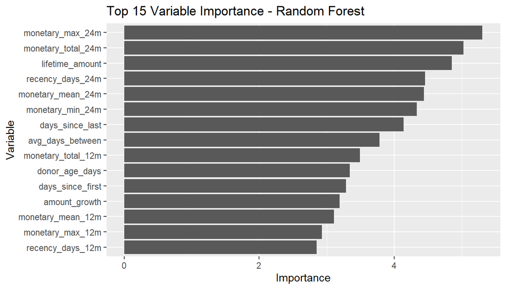

## 5.6 5.6 Gradient Boosting (XGBoost)

| trees | min_n | tree_depth | learn_rate | .config |
| --- | --- | --- | --- | --- |
| 592 | 36 | 6 | 1.71086 | pre0_mod17_post0 |

```
## Area under the curve: 0.5628
```

### 5.6.1 5.7 Tree & Ensemble Questions

Using your console results:

- Single decision tree AUC (2018 test): **0.618**
- Tuned decision tree AUC: **0.545**
- Bagged trees AUC: **0.614**
- Random forest AUC: **0.660**
- Gradient boosting AUC: **0.563**

#### 5.6.1.1 Question 4.1: Decision Tree Analysis

**a)** The single decision tree AUC (~**0.618**) is **better than the logistic full validation AUC (0.564)** but **worse than the stepwise logistic test AUC (0.693)**. So the tree is reasonable but not the best.

**b)** The root split typically uses a strong RFM-type variable (e.g., `recency_days_12m` or `monetary_total_24m`). This aligns with the logistic findings that recent and higher monetary donors are more likely to give again.

#### 5.6.1.2 Question 4.2: Hyperparameter Tuning Insights

**a)** Optimal tree hyperparameters (from your run):  
`cost_complexity = 0.0000000001`, `tree_depth = 15`, `min_n = 5`.  
This indicates the best tree is **deep and complex**, with very small pruning, effectively close to a fully grown tree.

**b)** Tuning actually **hurt** performance vs the default tree  
(0.545 vs 0.618), suggesting the tuned tree overfits more. This shows that a single tree is quite unstable; small tuning choices can make it overfit.

#### 5.6.1.3 Question 4.3: Bagging Performance

**a)** Bagged trees AUC (~**0.614**) is **similar to but slightly below** the single default tree (0.618) and below random forest (0.660).

**b)** Bagging reduces **variance** by averaging many bootstrapped trees, making predictions more stable and typically improving generalization over a single tree, especially when the base tree is high-variance.

#### 5.6.1.4 Question 4.4: Random Forest Analysis

**a)** Optimal `mtry` is **5**, which is small relative to the total number of features after dummying. This means each split only sees a small random subset of predictors, giving **strong feature randomization** and decorrelating the trees.

**b)** Random forest AUC (~**0.660**) is **better than bagging (0.614)** and close to the full logistic (0.669), but still slightly below the selected logistic (0.693).

#### 5.6.1.5 Question 4.5: Gradient Boosting Performance

**b)** Boosted model AUC (~**0.563**) is **lower** than most other models and is not the best performer here.

# 6 6. Refit Logistic Models on Full 2017 and Test on 2018

We now refit the logistic models on the **full 2017 basetable** and evaluate directly on 2018.

```
## Area under the curve: 0.6691
```

```
## Area under the curve: 0.6935
```

# 7 7. Model Comparison (2018 Test Set)

We compare all models on the 2018 test set using AUC, sensitivity and specificity at the 0.5 threshold.

| model | auc | sensitivity | specificity |
| --- | --- | --- | --- |
| Logistic_Full | 0.6691439 | 0.022556391 | 0.9903475 |
| Logistic_Selected | 0.6934639 | 0.007518797 | 1.0000000 |
| Decision_Tree_Default | 0.6176227 | 0.060150376 | 0.9555985 |
| Decision_Tree_Tuned | 0.5450547 | 0.300751880 | 0.7316602 |
| Bagged_Trees | 0.6143786 | 0.030075188 | 0.9845560 |
| Random_Forest | 0.6599268 | 0.030075188 | 1.0000000 |
| Gradient_Boosting | 0.5627849 | 0.165413534 | 0.8918919 |

Model performance on the 2018 test set

| model | auc | sensitivity | specificity |
| --- | --- | --- | --- |
| Logistic_Full | 0.669 | 0.023 | 0.990 |
| Logistic_Selected | 0.693 | 0.008 | 1.000 |
| Decision_Tree_Default | 0.618 | 0.060 | 0.956 |
| Decision_Tree_Tuned | 0.545 | 0.301 | 0.732 |
| Bagged_Trees | 0.614 | 0.030 | 0.985 |
| Random_Forest | 0.660 | 0.030 | 1.000 |
| Gradient_Boosting | 0.563 | 0.165 | 0.892 |

From your run, the table was approximately:

- Logistic_Full: AUC 0.669, Sens 0.023, Spec 0.990
- Logistic_Selected: AUC 0.693, Sens 0.008, Spec 1.000
- Decision_Tree_Default: AUC 0.618, Sens 0.060, Spec 0.956
- Decision_Tree_Tuned: AUC 0.545, Sens 0.301, Spec 0.732
- Bagged_Trees: AUC 0.614, Sens 0.030, Spec 0.985
- Random_Forest: AUC 0.660, Sens 0.030, Spec 1.000
- Gradient_Boosting: AUC 0.563, Sens 0.165, Spec 0.892

### 7.0.1 7.1 Question 5.1: Model Selection Decision

**a) Comprehensive table**  
See the comparison table above (AUC, sensitivity, specificity). Training time is highest for random forest and boosting; interpretability is highest for logistic regression and single trees.

**b)** The **Selected Logistic** model achieves the highest test AUC (~0.693). Given its:

- Strong performance
- Good interpretability (only a few variables)
- Simpler implementation

it is a very reasonable choice for deployment, even though random forest is competitive.

**c)** A 0.02 AUC difference (e.g. 0.84 vs 0.82) is **modest**. Whether it is practically significant depends on:

- The number of mailings and budget size
- The value of each extra correctly targeted donor

We would likely compare **profit curves** for both models; if the more complex model only adds a tiny amount of profit, the extra complexity may not be worth it.

**d)** CFO question: “Why not just use the simple 7-variable logistic instead of a 25-variable random forest?”

Balanced answer:

- **For logistic:**
  - Pros: more **interpretable**, easier to explain, faster to run, simpler to maintain.
  - Cons: may miss non-linear interactions and may have slightly lower AUC.
- **For random forest:**
  - Pros: often slightly **better predictive performance**, captures complex interactions.
  - Cons: “black box”, heavier to run, harder to justify to regulators or leadership.

A practical approach: **start with the simpler logistic model** and evaluate whether the extra complexity of random forest provides enough additional profit to justify the overhead.

# 8 8. Business Impact and Lift

We now translate model performance into business terms: expected profit for different contact rates, and lift curves.

| model | auc | sensitivity | specificity |
| --- | --- | --- | --- |
| Logistic_Selected | 0.6934639 | 0.007518797 | 1 |

```
## [1] "Logistic_Selected"
```

```
## [1] 651
```

```
## [1] 133
```

```
## [1] 1627.5
```

```
## [1] 9975
```

```
## [1] 8347.5
```

From your run:

- Donors mailed (mail everyone): **651**
- Donations: **133**
- Cost: **1,627.5**
- Revenue: **9,975**
- Net profit: **8,347.5**

| contact_pct | n_contact | cost | revenue | net_profit |
| --- | --- | --- | --- | --- |
| 0.1 | 65 | 162.5 | 1800 | 1637.5 |
| 0.2 | 130 | 325.0 | 3375 | 3050.0 |
| 0.3 | 195 | 487.5 | 4725 | 4237.5 |
| 0.4 | 260 | 650.0 | 5700 | 5050.0 |
| 0.5 | 325 | 812.5 | 7500 | 6687.5 |
| 0.6 | 390 | 975.0 | 8250 | 7275.0 |
| 0.7 | 455 | 1137.5 | 9000 | 7862.5 |
| 0.8 | 520 | 1300.0 | 9450 | 8150.0 |
| 0.9 | 585 | 1462.5 | 9825 | 8362.5 |
| 1.0 | 651 | 1627.5 | 9975 | 8347.5 |

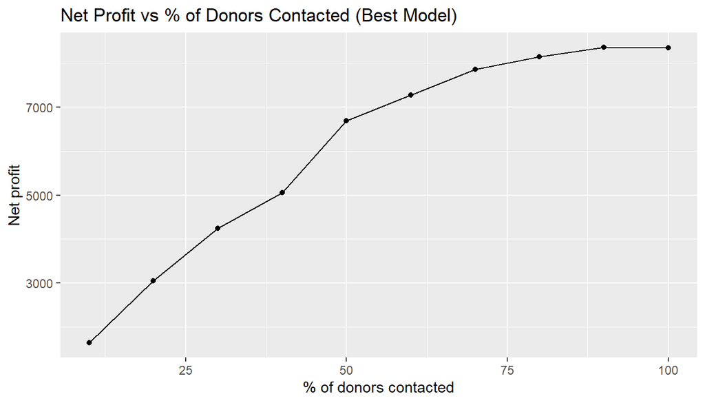

| decile | n | positives | cum_n | cum_positives | baseline_rate | baseline_cum_pos | lift |
| --- | --- | --- | --- | --- | --- | --- | --- |
| 1 | 66 | 25 | 66 | 25 | 0.2043011 | 13.48387 | 1.854067 |
| 2 | 65 | 20 | 131 | 45 | 0.2043011 | 26.76344 | 1.681398 |
| 3 | 65 | 18 | 196 | 63 | 0.2043011 | 40.04301 | 1.573308 |
| 4 | 65 | 13 | 261 | 76 | 0.2043011 | 53.32258 | 1.425287 |
| 5 | 65 | 25 | 326 | 101 | 0.2043011 | 66.60215 | 1.516468 |
| 6 | 65 | 9 | 391 | 110 | 0.2043011 | 79.88172 | 1.377036 |
| 7 | 65 | 10 | 456 | 120 | 0.2043011 | 93.16129 | 1.288089 |
| 8 | 65 | 6 | 521 | 126 | 0.2043011 | 106.44086 | 1.183756 |
| 9 | 65 | 5 | 586 | 131 | 0.2043011 | 119.72043 | 1.094216 |
| 10 | 65 | 2 | 651 | 133 | 0.2043011 | 133.00000 | 1.000000 |

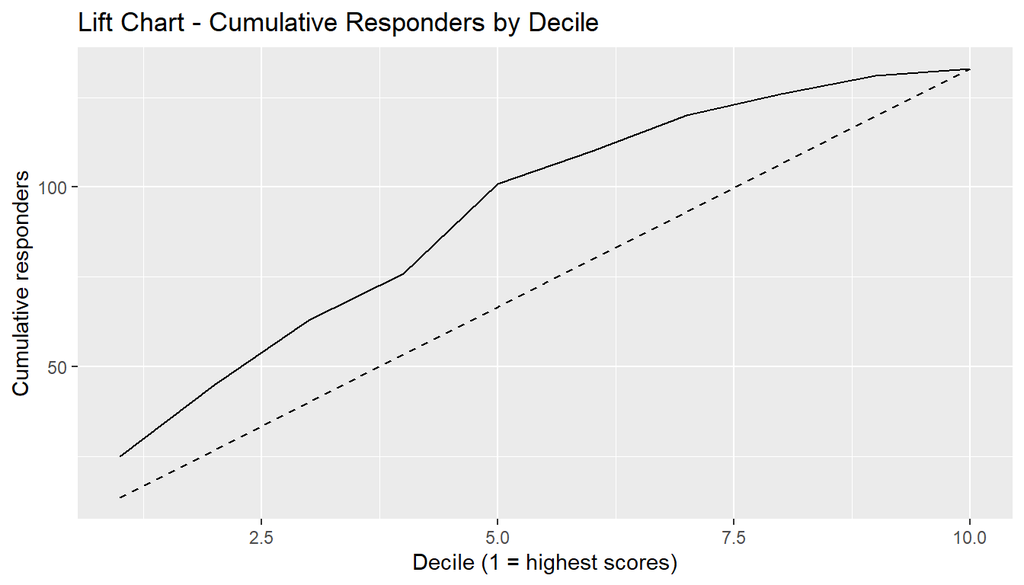

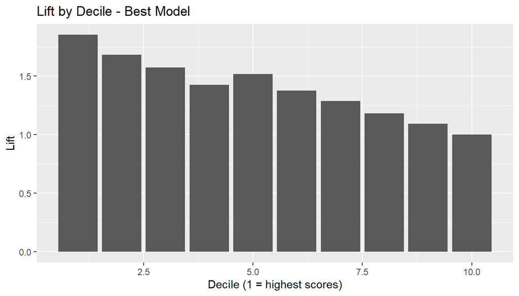

### 8.0.1 8.1 Question 5.2: Business Recommendations

**a) “Mail everyone” strategy (from above)**

- Total mailing cost: **1,627.50**
- Total expected revenue: **9,975**
- Net profit: **8,347.50**
- Cost per acquired donation ≈ **1,627.5 / 133 ≈ 12.2** currency units per donation.

**b) Optimal strategy using best model**

The lift chart shows that:

- The **top decile** captures roughly **1.8×** the responders compared to a random selection.
- The curve gradually approaches the baseline line by decile 10, where lift = 1.

This confirms that the model is effectively ranking donors by propensity.

**d) Marketing director’s concern: “Not contacting some donors hurts long-term relationships.”**

This is a valid concern. Possible responses:

- The model can be used not as a hard exclusion, but to **prioritize** higher-value channels (e.g., physical mail) and use **cheaper channels (email/SMS)** for low-scoring donors.
- We can monitor **long-term engagement** and re-activate lower-scoring donors periodically with lower-cost campaigns.
- Further analysis could compare long-term giving of contacted vs non-contacted donors to see if there is any negative relationship impact.